# TCGA ids

Marchionni Lab

# TCGA

## Get Data

All data and code can be retrieved from https://github.com/c1au6i0/tcga_metadata.

Download Biospecimen and Clinical data (in `csv`) from the [TCGA-PRAD website](https://portal.gdc.cancer.gov/projects/TCGA-PRAD) in `data` folder.

Info on the ids can be found [here](https://docs.cancergenomicscloud.org/docs/tcga-metadata#section-case)

And some below useful pics from TCGA website.

Barcodes:

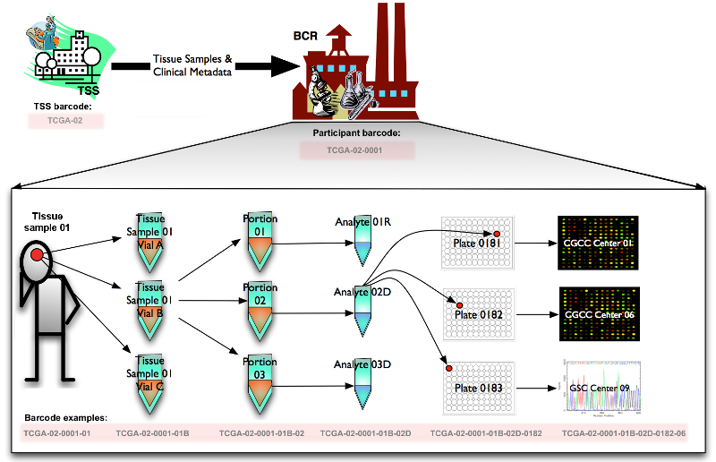

And the hierarchy:

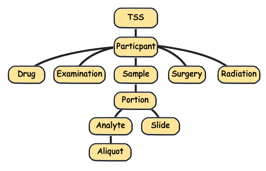

## Clinical Info

This is to untar, import and clean up the clinical info.

```r
library(here)
library(tidyverse)

untar(here("data", "dna_whole", "clinical.project-TCGA-PRAD.2020-11-20.tar.gz"), exdir = here("data", "dna_whole", "clinical"))


to_imp <- list.files(here("data", "dna_whole", "clinical"), full.names = TRUE)

clinical <- lapply(to_imp, read.delim)
names(clinical) <- sub("\\.tsv", "", list.files(here("data", "dna_whole", "clinical")))

clean_data <- function(dat){
  dat[dat == "Not Reported"| dat == "'--"] <- NA
  # dat[dat == "'--"] <- NA
  dat %>%
     select(where(~!all(is.na(.))))
}
```

Only one of the files has not empty columns. Family history and exposure are empty… This a list of the **metadata files relative to clinical data** and their identifiers.

```r
clinical <- lapply(clinical, clean_data)

lapply(clinical, names)
```

```
## $clinical
##  [1] "case_id"                     "case_submitter_id"
##  [3] "project_id"                  "age_at_index"
##  [5] "days_to_birth"               "days_to_death"
##  [7] "ethnicity"                   "gender"
##  [9] "race"                        "vital_status"
## [11] "year_of_birth"               "year_of_death"
## [13] "age_at_diagnosis"            "ajcc_clinical_m"
## [15] "ajcc_clinical_t"             "ajcc_pathologic_n"
## [17] "ajcc_pathologic_t"           "classification_of_tumor"
## [19] "days_to_diagnosis"           "days_to_last_follow_up"
## [21] "icd_10_code"                 "last_known_disease_status"
## [23] "morphology"                  "primary_diagnosis"
## [25] "primary_gleason_grade"       "prior_malignancy"
## [27] "prior_treatment"             "progression_or_recurrence"
## [29] "secondary_gleason_grade"     "site_of_resection_or_biopsy"
## [31] "synchronous_malignancy"      "tissue_or_organ_of_origin"
## [33] "tumor_grade"                 "tumor_stage"
## [35] "year_of_diagnosis"           "treatment_or_therapy"
## [37] "treatment_type"
##
## $exposure
## [1] "case_id"           "case_submitter_id" "project_id"
##
## $family_history
## character(0)
```

## Biospecimen Info

This is to untar, import and clean up the biospecimen info.

```r
untar(here("data", "dna_whole", "biospecimen.project-TCGA-PRAD.2020-11-19.tar.gz"), exdir = here("data", "dna_whole", "biospecimen"))

to_imp <- list.files(here("data", "dna_whole", "biospecimen"), full.names = TRUE)

biospecimen <- lapply(to_imp, read.delim)
names(biospecimen) <- sub("\\.tsv", "", list.files(here("data", "dna_whole", "biospecimen")))
```

This a list of the **metadata files relative to biospeciments** and their identifiers.

```r
biospecimen <- lapply(biospecimen, clean_data)

lapply(biospecimen, names)
```

```
## $aliquot
##  [1] "project_id"           "case_id"              "case_submitter_id"
##  [4] "sample_id"            "sample_submitter_id"  "portion_id"
##  [7] "portion_submitter_id" "analyte_id"           "analyte_submitter_id"
## [10] "aliquot_id"           "aliquot_submitter_id" "analyte_type"
## [13] "concentration"        "source_center"        "state"
##
## $analyte
##  [1] "project_id"               "case_id"
##  [3] "case_submitter_id"        "sample_id"
##  [5] "sample_submitter_id"      "portion_id"
##  [7] "portion_submitter_id"     "analyte_id"
##  [9] "analyte_submitter_id"     "a260_a280_ratio"
## [11] "analyte_type"             "analyte_type_id"
## [13] "concentration"            "spectrophotometer_method"
```

[output cut: 30 more lines]

```r
# IDS shared among datasets
ids <- Reduce(intersect, lapply(biospecimen, names))

all_bios <- plyr::join_all(biospecimen, by = ids, type = "full")
```

## Single Flat File

We create a single file with all info and recode the analyte types based on the codes.

```r
# IDS shared among datasets
ids_2 <- Reduce(intersect, lapply(list(clinical$clinical, all_bios), names))

all_ann <- full_join(clinical$clinical, all_bios, by = ids_2)

all_ann <- all_ann %>%
  mutate(analyte_type_id = recode(analyte_type_id,
    "W" = "Whole Genome Amplification",
    "D" = "DNA",
    "H" = "mirVana RNA",
    "R" = "RNA",
    "T" = "total RNA",
    "x" = "Whole Genome Amplification second reaction"
  ))
```

Number of patients:

```r
length(unique(all_ann$case_submitter_id))
```

```
## [1] 500
```

# ICGC

These are the ids. Go to https://dcc.icgc.org/analysis/sets, save donor set, download donor set and check clinical data.

```r
donors <- list(
  "TCGA-CH-5763",
  "TCGA-EJ-5506",
  "TCGA-HI-7169",
  "TCGA-CH-5788",
  "TCGA-EJ-5503",

  "TCGA-HC-8258",
  "TCGA-HC-7233",
  "TCGA-G9-6336",
  "TCGA-HC-7079",
  "TCGA-EJ-7791",

  "TCGA-HC-7737",
  "TCGA-CH-5771",
  "TCGA-G9-7522",
  "TCGA-CH-5789",
  "TCGA-HC-7744",

  "TCGA-G9-6370",
  "TCGA-G9-6365",
  "TCGA-HC-7740",
  "TCGA-HC-7075",
  "TCGA-CH-5750"
)
```

```r
whole_genome_samples <- clinical$clinical %>%
  filter(case_submitter_id %in% !!donors) %>%
  pivot_wider(names_from = "treatment_type", values_from = "treatment_or_therapy")
```

Number of patients:

```r
length(unique(whole_genome_samples$case_submitter_id))
```

```
## [1] 20
```

```r
whole_genome_samples %>%
  mutate(across(where(is.character), as.factor)) %>%
  skimr::skim()
```

Data summary

| Name | Piped data |
| --- | --- |
| Number of rows | 20 |
| Number of columns | 37 |
| _______________________ |  |
| Column type frequency: |  |
| factor | 36 |
| numeric | 1 |
| ________________________ |  |
| Group variables | None |

**Variable type: factor**

| skim_variable | n_missing | complete_rate | ordered | n_unique | top_counts |
| --- | --- | --- | --- | --- | --- |
| case_id | 0 | 1.00 | FALSE | 20 | 10f: 1, 11f: 1, 18e: 1, 3ac: 1 |
| case_submitter_id | 0 | 1.00 | FALSE | 20 | TCG: 1, TCG: 1, TCG: 1, TCG: 1 |
| project_id | 0 | 1.00 | FALSE | 1 | TCG: 20 |
| days_to_birth | 2 | 0.90 | FALSE | 18 | -17: 1, -18: 1, -18: 1, -18: 1 |
| days_to_death | 20 | 0.00 | FALSE | 0 | : |
| ethnicity | 0 | 1.00 | FALSE | 2 | not: 18, not: 2 |
| gender | 0 | 1.00 | FALSE | 1 | mal: 20 |
| race | 0 | 1.00 | FALSE | 2 | whi: 18, bla: 2 |
| vital_status | 0 | 1.00 | FALSE | 1 | Ali: 20 |
| year_of_birth | 0 | 1.00 | FALSE | 17 | 193: 2, 194: 2, 195: 2, 193: 1 |
| year_of_death | 20 | 0.00 | FALSE | 0 | : |
| age_at_diagnosis | 2 | 0.90 | FALSE | 18 | 170: 1, 180: 1, 183: 1, 187: 1 |
| ajcc_clinical_m | 3 | 0.85 | FALSE | 1 | M0: 17 |
| ajcc_clinical_t | 8 | 0.60 | FALSE | 6 | T1c: 5, T2a: 2, T2b: 2, T2c: 1 |
| ajcc_pathologic_n | 1 | 0.95 | FALSE | 2 | N0: 16, N1: 3 |
| ajcc_pathologic_t | 1 | 0.95 | FALSE | 5 | T2c: 7, T3a: 5, T3b: 4, T2a: 2 |
| classification_of_tumor | 0 | 1.00 | FALSE | 1 | not: 20 |
| days_to_diagnosis | 0 | 1.00 | FALSE | 1 | 0: 20 |
| days_to_last_follow_up | 0 | 1.00 | FALSE | 19 | 396: 2, 107: 1, 109: 1, 111: 1 |
| icd_10_code | 0 | 1.00 | FALSE | 1 | C61: 20 |
| last_known_disease_status | 0 | 1.00 | FALSE | 1 | not: 20 |
| morphology | 0 | 1.00 | FALSE | 1 | 814: 20 |
| primary_diagnosis | 0 | 1.00 | FALSE | 1 | Ade: 20 |
| primary_gleason_grade | 0 | 1.00 | FALSE | 3 | Pat: 14, Pat: 4, Pat: 2 |
| prior_malignancy | 0 | 1.00 | FALSE | 2 | no: 18, yes: 2 |
| prior_treatment | 0 | 1.00 | FALSE | 1 | No: 20 |
| progression_or_recurrence | 0 | 1.00 | FALSE | 1 | not: 20 |
| secondary_gleason_grade | 0 | 1.00 | FALSE | 2 | Pat: 12, Pat: 8 |
| site_of_resection_or_biopsy | 0 | 1.00 | FALSE | 1 | Pro: 20 |
| synchronous_malignancy | 2 | 0.90 | FALSE | 1 | No: 18 |
| tissue_or_organ_of_origin | 0 | 1.00 | FALSE | 1 | Pro: 20 |
| tumor_grade | 0 | 1.00 | FALSE | 1 | not: 20 |
| tumor_stage | 0 | 1.00 | FALSE | 1 | not: 20 |
| year_of_diagnosis | 0 | 1.00 | FALSE | 6 | 201: 6, 201: 5, 200: 3, 200: 2 |
| Radiation Therapy, NOS | 0 | 1.00 | FALSE | 2 | no: 18, yes: 2 |
| Pharmaceutical Therapy, NOS | 0 | 1.00 | FALSE | 2 | no: 19, yes: 1 |

**Variable type: numeric**

| skim_variable | n_missing | complete_rate | mean | sd | p0 | p25 | p50 | p75 | p100 | hist |
| --- | --- | --- | --- | --- | --- | --- | --- | --- | --- | --- |
| age_at_index | 0 | 1 | 60.1 | 8.29 | 46 | 54.25 | 60 | 67 | 73 | ▆▆▅▇▆ |

```r
all_ann %>%
  mutate(across(where(is.character), as.factor)) %>%
  skimr::skim()
```

Data summary

| Name | Piped data |
| --- | --- |
| Number of rows | 63548 |
| Number of columns | 78 |
| _______________________ |  |
| Column type frequency: |  |
| factor | 76 |
| numeric | 2 |
| ________________________ |  |
| Group variables | None |

**Variable type: factor**

| skim_variable | n_missing | complete_rate | ordered | n_unique | top_counts |
| --- | --- | --- | --- | --- | --- |
| case_id | 0 | 1.00 | FALSE | 500 | 607: 976, 5e2: 740, d77: 740, 666: 660 |
| case_submitter_id | 0 | 1.00 | FALSE | 500 | TCG: 976, TCG: 740, TCG: 740, TCG: 660 |
| project_id | 0 | 1.00 | FALSE | 1 | TCG: 63548 |
| days_to_birth | 1038 | 0.98 | FALSE | 464 | -23: 1234, -18: 740, -26: 740, -21: 660 |
| days_to_death | 62620 | 0.01 | FALSE | 10 | 132: 216, 875: 116, 185: 104, 246: 88 |
| ethnicity | 0 | 1.00 | FALSE | 3 | not: 51834, not: 11296, his: 418 |
| gender | 0 | 1.00 | FALSE | 1 | mal: 63548 |
| race | 0 | 1.00 | FALSE | 5 | whi: 54380, bla: 6398, asi: 1478, not: 1230 |
| vital_status | 336 | 0.99 | FALSE | 2 | Ali: 62284, Dea: 928 |
| year_of_birth | 1910 | 0.97 | FALSE | 36 | 194: 3644, 194: 3540, 195: 3498, 194: 3402 |
| year_of_death | 62796 | 0.01 | FALSE | 5 | 201: 332, 201: 240, 201: 66, 200: 62 |
| age_at_diagnosis | 1038 | 0.98 | FALSE | 464 | 234: 1234, 186: 740, 261: 740, 214: 660 |
| ajcc_clinical_m | 4600 | 0.93 | FALSE | 4 | M0: 58762, M1b: 66, M1c: 62, M1a: 58 |
| ajcc_clinical_t | 13226 | 0.79 | FALSE | 10 | T1c: 19820, T2a: 6610, T2c: 6588, T2b: 6578 |
| ajcc_pathologic_n | 9078 | 0.86 | FALSE | 2 | N0: 45810, N1: 8660 |
| ajcc_pathologic_t | 1032 | 0.98 | FALSE | 6 | T3a: 22566, T2c: 19510, T3b: 16480, T4: 1420 |
| classification_of_tumor | 0 | 1.00 | FALSE | 1 | not: 63548 |
| days_to_diagnosis | 1910 | 0.97 | FALSE | 1 | 0: 61638 |
| days_to_last_follow_up | 752 | 0.99 | FALSE | 436 | 432: 976, 31: 948, 91: 790, 102: 740 |
| icd_10_code | 0 | 1.00 | FALSE | 2 | C61: 63448, C61: 100 |
| last_known_disease_status | 0 | 1.00 | FALSE | 1 | not: 63548 |
| morphology | 0 | 1.00 | FALSE | 4 | 814: 61198, 850: 1270, 825: 980, 848: 100 |
| primary_diagnosis | 0 | 1.00 | FALSE | 4 | Ade: 61198, Inf: 1270, Ade: 980, Muc: 100 |
| primary_gleason_grade | 0 | 1.00 | FALSE | 4 | Pat: 32878, Pat: 25892, Pat: 4564, Pat: 214 |
| prior_malignancy | 0 | 1.00 | FALSE | 2 | no: 59566, yes: 3982 |
| prior_treatment | 0 | 1.00 | FALSE | 2 | No: 63398, Yes: 150 |
| progression_or_recurrence | 0 | 1.00 | FALSE | 1 | not: 63548 |
| secondary_gleason_grade | 0 | 1.00 | FALSE | 3 | Pat: 30094, Pat: 19026, Pat: 14428 |
| site_of_resection_or_biopsy | 0 | 1.00 | FALSE | 1 | Pro: 63548 |
| synchronous_malignancy | 2048 | 0.97 | FALSE | 2 | No: 61438, Yes: 62 |
| tissue_or_organ_of_origin | 0 | 1.00 | FALSE | 1 | Pro: 63548 |
| tumor_grade | 0 | 1.00 | FALSE | 1 | not: 63548 |
| tumor_stage | 0 | 1.00 | FALSE | 1 | not: 63548 |
| year_of_diagnosis | 1910 | 0.97 | FALSE | 13 | 201: 13594, 200: 9458, 201: 8194, 201: 7352 |
| treatment_or_therapy | 0 | 1.00 | FALSE | 3 | no: 48955, yes: 9445, not: 5148 |
| treatment_type | 0 | 1.00 | FALSE | 2 | Pha: 31774, Rad: 31774 |
| sample_id | 0 | 1.00 | FALSE | 1466 | 46b: 960, a6f: 720, aeb: 720, d16: 640 |
| sample_submitter_id | 0 | 1.00 | FALSE | 1466 | TCG: 960, TCG: 720, TCG: 720, TCG: 640 |
| portion_id | 898 | 0.99 | FALSE | 1538 | 5c6: 720, 5cb: 560, d66: 560, 29c: 480 |
| portion_submitter_id | 1784 | 0.97 | FALSE | 1095 | TCG: 720, TCG: 560, TCG: 560, TCG: 480 |
| analyte_id | 1784 | 0.97 | FALSE | 2557 | b4e: 360, 1ec: 320, f17: 320, 51a: 288 |
| analyte_submitter_id | 1784 | 0.97 | FALSE | 2557 | TCG: 360, TCG: 320, TCG: 320, TCG: 288 |
| aliquot_id | 1784 | 0.97 | FALSE | 5808 | 06c: 120, 4e6: 120, 56a: 120, 579: 120 |
| aliquot_submitter_id | 1784 | 0.97 | FALSE | 5808 | TCG: 120, TCG: 120, TCG: 120, TCG: 120 |
| analyte_type | 62368 | 0.02 | FALSE | 1 | DNA: 1180 |
| concentration | 2964 | 0.95 | FALSE | 13 | 0.1: 13986, 0.1: 12210, 0.5: 8596, 0.1: 6974 |
| source_center | 2964 | 0.95 | FALSE | 2 | 23: 33764, 22: 26820 |
| state | 886 | 0.99 | FALSE | 1 | rel: 62662 |
| a260_a280_ratio | 42898 | 0.32 | FALSE | 36 | 1.9: 6066, 1.8: 5480, 1.8: 1058, 1.7: 872 |
| analyte_type_id | 4016 | 0.94 | FALSE | 3 | DNA: 22428, Who: 19498, RNA: 17606 |
| spectrophotometer_method | 13150 | 0.79 | FALSE | 2 | UV : 28516, Pic: 21882 |
| creation_datetime | 1784 | 0.97 | FALSE | 218 | 137: 13126, 140: 7938, 129: 3072, 130: 2314 |
| is_ffpe | 886 | 0.99 | FALSE | 2 | Fal: 61628, Tru: 1034 |
| portion_number | 1784 | 0.97 | FALSE | 14 | 11: 21446, 21: 20000, 01: 11794, 31: 3194 |
| weight | 27568 | 0.57 | FALSE | 52 | 30.: 15376, 20.: 3732, 2.0: 2132, 35.: 1338 |
| days_to_collection | 34930 | 0.45 | FALSE | 263 | 209: 1024, 239: 720, 757: 720, 165: 656 |
| days_to_sample_procurement | 62650 | 0.01 | FALSE | 1 | 0: 898 |
| initial_weight | 36324 | 0.43 | FALSE | 75 | 300: 2236, 140: 1180, 160: 990, 130: 976 |
| intermediate_dimension | 35580 | 0.44 | FALSE | 17 | 1.0: 5702, 0.4: 4538, 0.6: 3352, 0.8: 3188 |
| longest_dimension | 35580 | 0.44 | FALSE | 21 | 1.0: 4648, 1.3: 2864, 1.2: 2496, 1.4: 2396 |
| oct_embedded | 32246 | 0.49 | FALSE | 3 | tru: 24872, fal: 5532, No: 898 |
| pathology_report_uuid | 11168 | 0.82 | FALSE | 501 | 059: 960, B31: 720, D1D: 720, 007: 640 |
| preservation_method | 62650 | 0.01 | FALSE | 1 | FFP: 898 |
| sample_type | 886 | 0.99 | FALSE | 4 | Pri: 53258, Blo: 6592, Sol: 2792, Met: 20 |
| shortest_dimension | 35580 | 0.44 | FALSE | 8 | 0.3: 8980, 0.4: 8922, 0.2: 4754, 0.5: 2698 |
| slide_id | 7626 | 0.88 | FALSE | 1188 | b97: 720, cab: 720, 2da: 640, cd8: 640 |
| slide_submitter_id | 7626 | 0.88 | FALSE | 1188 | TCG: 720, TCG: 720, TCG: 640, TCG: 640 |
| percent_lymphocyte_infiltration | 17934 | 0.72 | FALSE | 19 | 0.0: 23856, 2.0: 7580, 3.0: 3552, 40.: 3324 |
| percent_monocyte_infiltration | 18030 | 0.72 | FALSE | 8 | 0.0: 36692, 20.: 3324, 1.0: 2172, 2.0: 1782 |
| percent_necrosis | 11406 | 0.82 | FALSE | 10 | 0.0: 46914, 2.0: 1902, 5.0: 1092, 1.0: 1038 |
| percent_neutrophil_infiltration | 17934 | 0.72 | FALSE | 5 | 0.0: 39600, 20.: 3816, 1.0: 1314, 2.0: 872 |
| percent_normal_cells | 12486 | 0.80 | FALSE | 24 | 0.0: 12704, 10.: 7720, 20.: 6312, 15.: 6102 |
| percent_stromal_cells | 12486 | 0.80 | FALSE | 54 | 20.: 8830, 15.: 6064, 30.: 4980, 25.: 4458 |
| percent_tumor_cells | 12486 | 0.80 | FALSE | 37 | 70.: 8206, 60.: 7210, 80.: 5604, 50.: 4940 |
| percent_tumor_nuclei | 11310 | 0.82 | FALSE | 27 | 70.: 9756, 60.: 9106, 80.: 8488, 75.: 5316 |
| section_location | 8512 | 0.87 | FALSE | 2 | TOP: 44494, BOT: 10542 |

**Variable type: numeric**

| skim_variable | n_missing | complete_rate | mean | sd | p0 | p25 | p50 | p75 | p100 | hist |
| --- | --- | --- | --- | --- | --- | --- | --- | --- | --- | --- |
| age_at_index | 0 | 1.00 | 61.06 | 6.82 | 41 | 56 | 61.5 | 66 | 78 | ▁▅▇▇▂ |
| sample_type_id | 886 | 0.99 | 2.39 | 3.32 | 1 | 1 | 1.0 | 1 | 11 | ▇▁▁▁▂ |

```r
View(all_ann)
```

```r
ICGC_ids <- read.delim(here::here("data", "dna_whole", "ICGC_donors.tsv"))

dput(unique(ICGC_ids$ICGC.Donor))
```

```
## c("DO36372", "DO36352", "DO36283", "DO36239", "DO49815", "DO36285",
## "DO36248", "DO36273", "DO36335", "DO36262", "DO36361", "DO36265",
## "DO36253", "DO36345", "DO36356", "DO36226", "DO36360", "DO46813",
## "DO36254", "DO36359")
```